# Publication bias in experimental philosophy: analysis report

# Awareness/implications

## [I1] Before participating in this study, were you aware of the issue of many scientific results remaining unpublished for reasons not related to their scientific quality (sometimes referred to as the “file drawer problem” or “publication bias”)?

| I1 | n | % |
| --- | --- | --- |
| No | 4 | 8.00 |
| Yes | 46 | 92.00 |

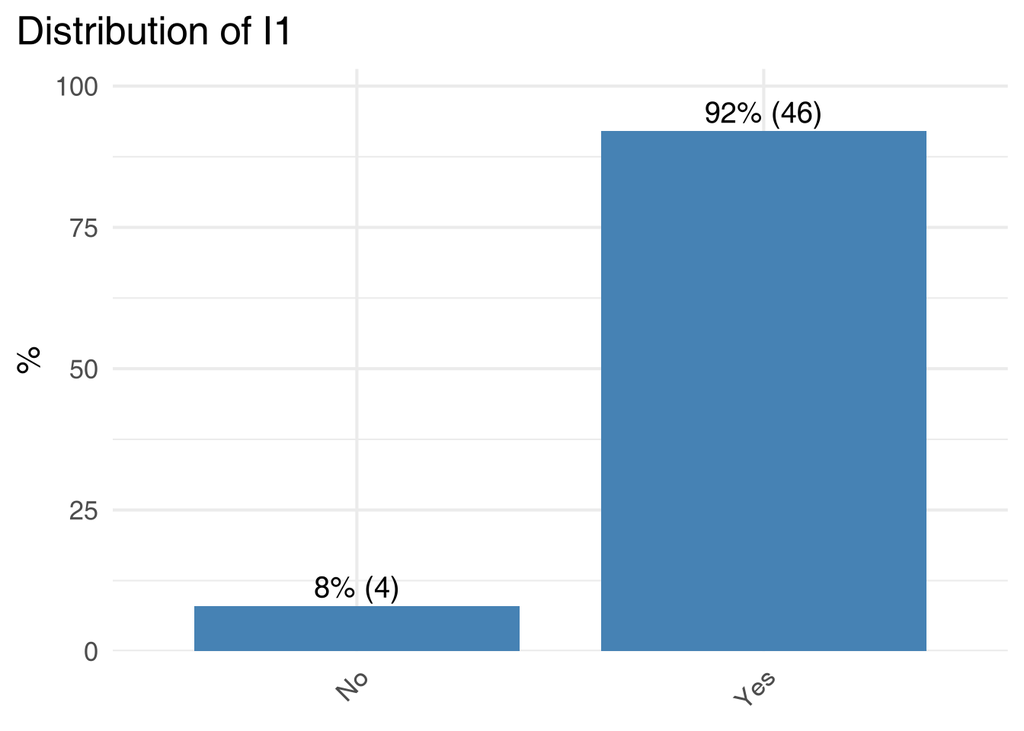

## [I2] How familiar are you with this issue?

| I2 | n | % |
| --- | --- | --- |
| 1 - Not at all familiar | 0 | 0.00 |
| 2 | 6 | 12.00 |
| 3 | 6 | 12.00 |
| 4 | 14 | 28.00 |
| 5 - Very familiar | 20 | 40.00 |
|  | 4 | 8.00 |

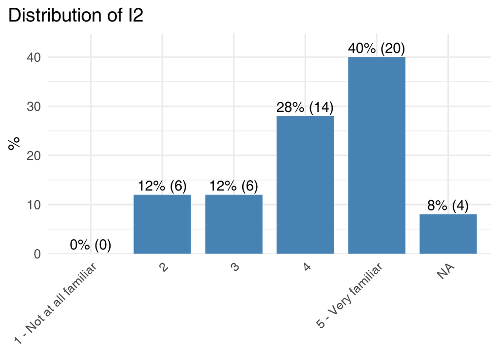

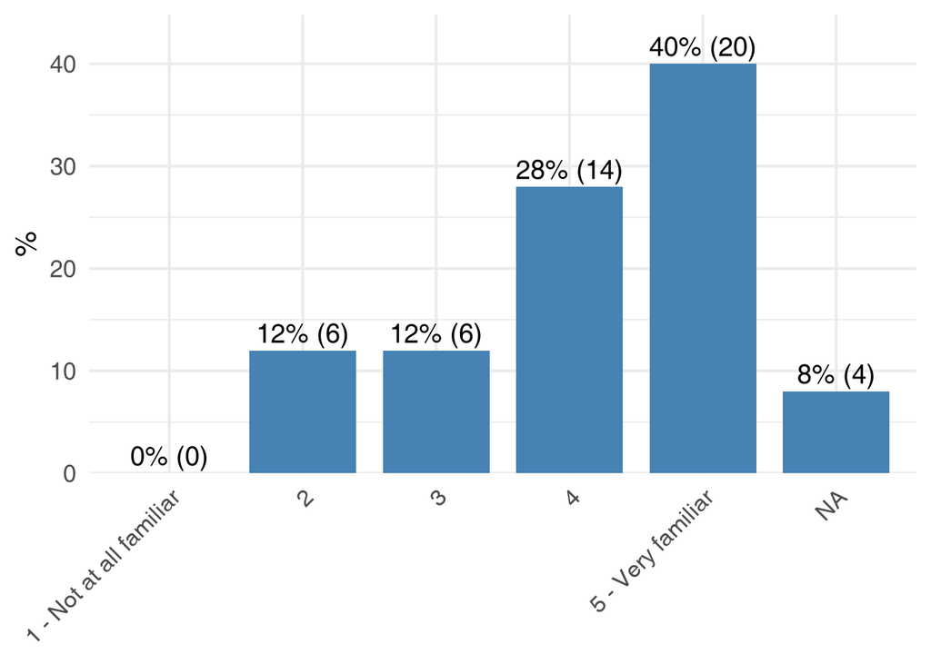

## [I3] In your opinion, does the “file drawer problem” apply to experimental philosophy research?

| I3 | n | % |
| --- | --- | --- |
| 1 - Definitely not | 0 | 0.00 |
| 2 | 4 | 8.00 |
| 3 | 14 | 28.00 |
| 4 | 14 | 28.00 |
| 5 - Definitely yes | 18 | 36.00 |

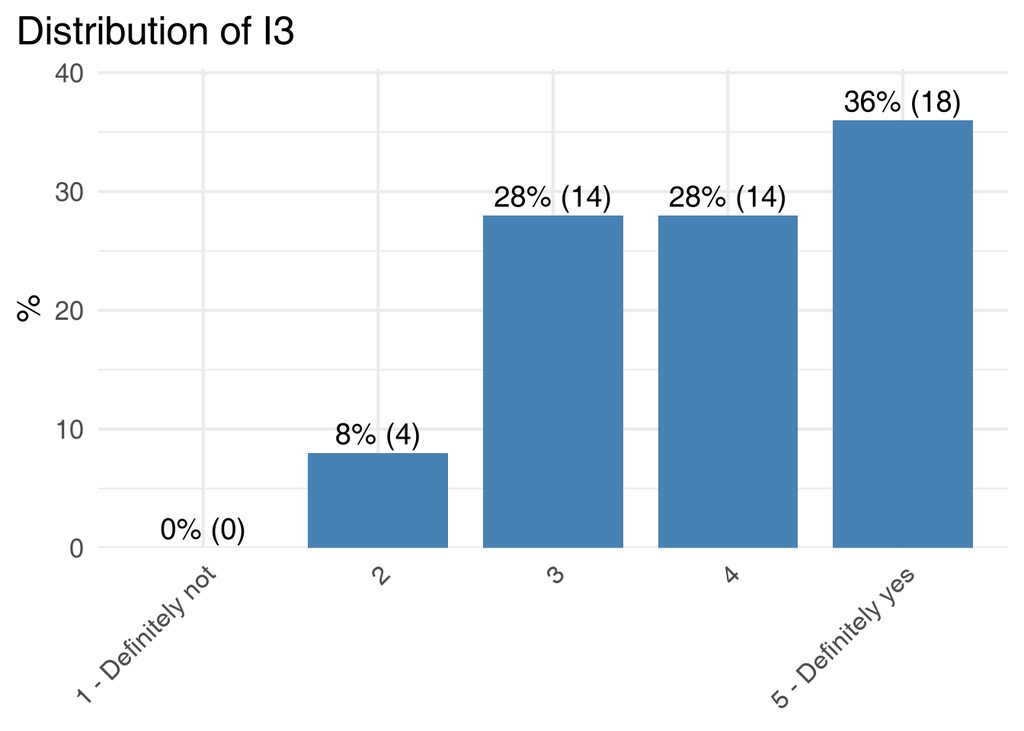

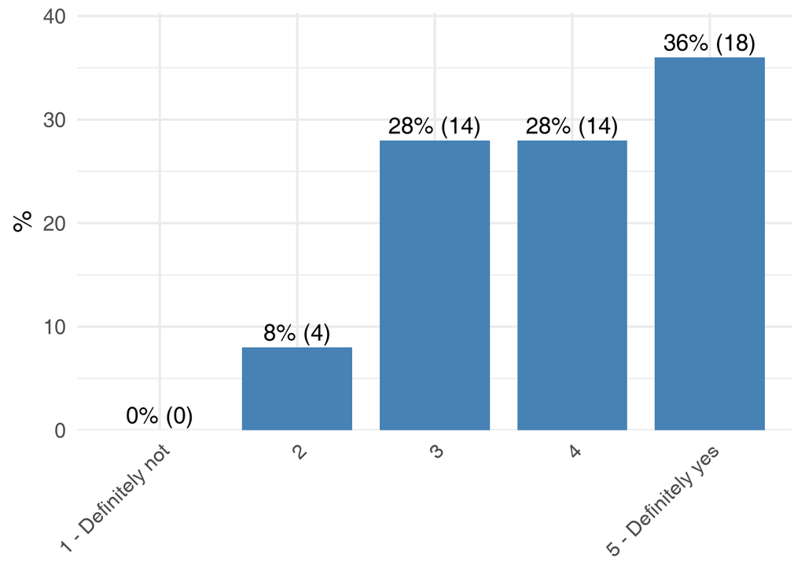

## [I4] Please indicate your familiarity with the following possible consequences of the file drawer problem, as well as how severe you believe each consequence is for the quality of research in experimental philosophy.

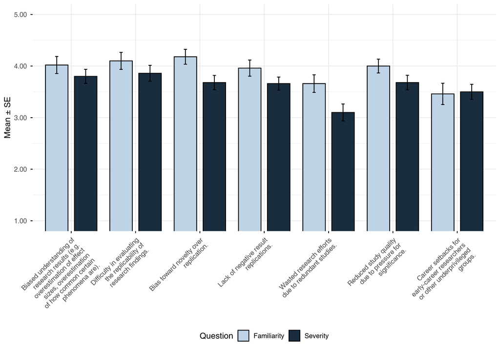

| Consequence | Question | n | M | SD | SE |
| --- | --- | --- | --- | --- | --- |
| Biased understanding of research results (e.g. overestimation of effect sizes, overestimation of how common certain phenomena are). | Familiarity | 50 | 4.02 | 1.17 | 0.17 |
| Biased understanding of research results (e.g. overestimation of effect sizes, overestimation of how common certain phenomena are). | Severity | 50 | 3.80 | 0.97 | 0.14 |
| Difficulty in evaluating the replicability of research findings. | Familiarity | 50 | 4.10 | 1.16 | 0.16 |
| Difficulty in evaluating the replicability of research findings. | Severity | 50 | 3.86 | 1.09 | 0.15 |
| Bias toward novelty over replication. | Familiarity | 50 | 4.18 | 1.02 | 0.14 |
| Bias toward novelty over replication. | Severity | 50 | 3.68 | 0.98 | 0.14 |
| Lack of negative result replications. | Familiarity | 50 | 3.96 | 1.11 | 0.16 |
| Lack of negative result replications. | Severity | 50 | 3.66 | 0.89 | 0.13 |
| Wasted research efforts due to redundant studies. | Familiarity | 50 | 3.66 | 1.21 | 0.17 |
| Wasted research efforts due to redundant studies. | Severity | 50 | 3.10 | 1.16 | 0.16 |
| Reduced study quality due to pressure for significance. | Familiarity | 50 | 4.00 | 0.95 | 0.13 |
| Reduced study quality due to pressure for significance. | Severity | 50 | 3.68 | 1.00 | 0.14 |
| Career setbacks for early-career researchers or other underprivileged groups. | Familiarity | 50 | 3.46 | 1.46 | 0.21 |
| Career setbacks for early-career researchers or other underprivileged groups. | Severity | 50 | 3.50 | 1.04 | 0.15 |

## [I5] Below is a list of research practices that are sometimes considered problematic in scientific research, including the file drawer problem. Please rate how acceptable you believe these practices are within the community of experimental philosophers.

| Scale | n | M | SD | SE |
| --- | --- | --- | --- | --- |
| Removing whole items/cases knowingly / purposefully to obtain favorable results | 49 | 4.80 | 0.58 | 0.08 |
| Cherry-picking data to analyze | 49 | 4.41 | 0.89 | 0.13 |
| Not being transparent with regard to the reporting on what steps were taken for data cleaning (e.g., removing cases/items without a stated criterion or justification for doing so) | 49 | 4.39 | 0.81 | 0.12 |
| Fishing for results by collecting information on unnecessary variables | 50 | 4.16 | 0.98 | 0.14 |
| Employing selective reporting of results/instruments | 50 | 4.16 | 0.91 | 0.13 |
| Selecting variables out of convenience and/or familiarity when more theoretically grounded variables are available | 49 | 3.37 | 1.01 | 0.14 |
| Not attempting to publish results in a timely manner | 48 | 2.42 | 0.99 | 0.14 |

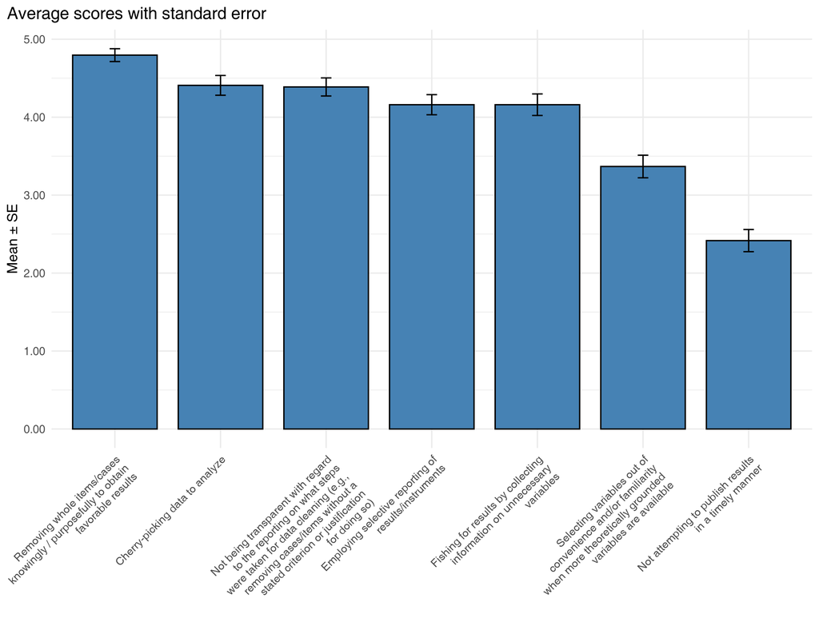

# Solutions

## [S1] Do your research sponsors (e.g., your institution, ethics review committee, or funding agency) require you to do any of the following?

| Option | n | % |
| --- | --- | --- |
| Develop a data management plan before starting the research. | 25 | 50.00 |
| None of the above. | 19 | 38.00 |
| Make research data publicly available. | 18 | 36.00 |
| Publish in open access journals. | 16 | 32.00 |
| Upload preprints or articles to a public repository. | 10 | 20.00 |

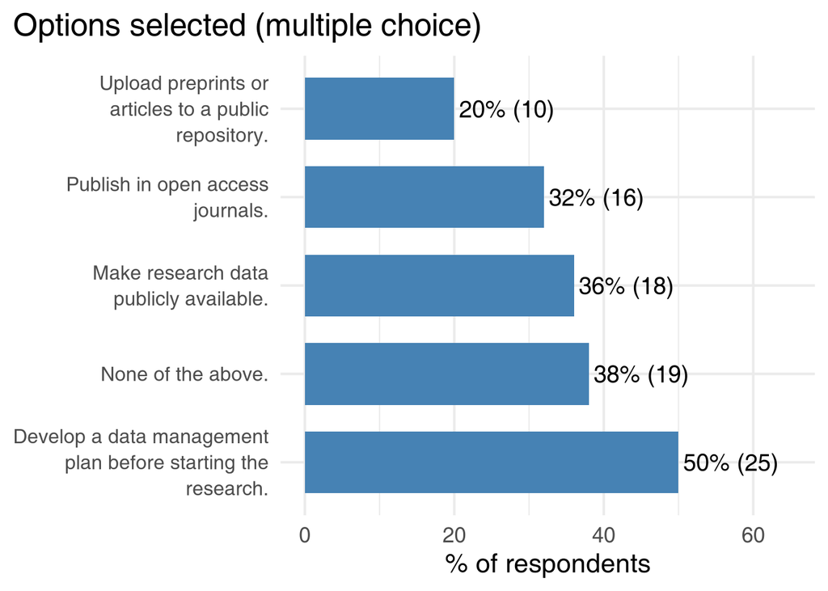

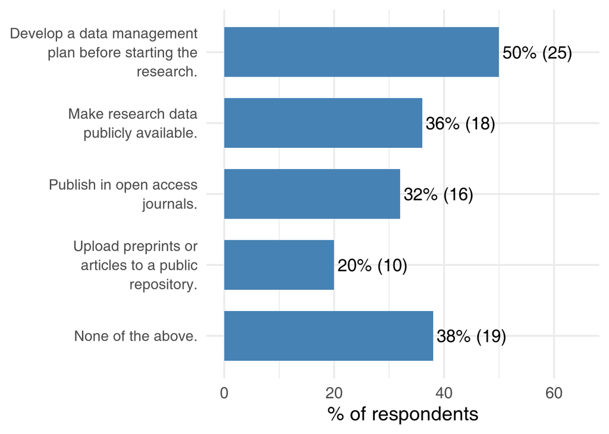

## [S2] Does your current organization or institution provide any of the following resources or support?

| Option | n | % |
| --- | --- | --- |
| Funding for publishing in open access journals. | 34 | 68.00 |
| An institutional repository for scientific publications. | 26 | 52.00 |
| A research data repository. | 16 | 32.00 |
| None of the above. | 9 | 18.00 |
| Assistance in disseminating research results or preprints. | 8 | 16.00 |
| Citable digital object identifiers (DOIs) for datasets or research reports. | 7 | 14.00 |

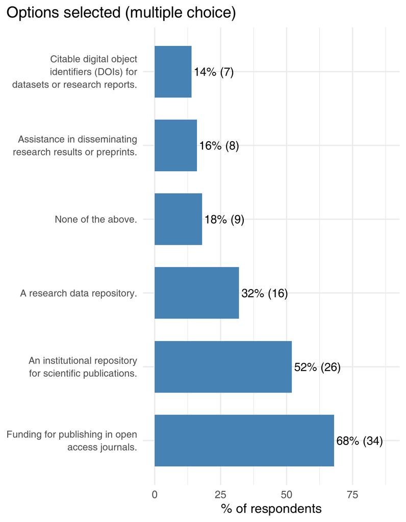

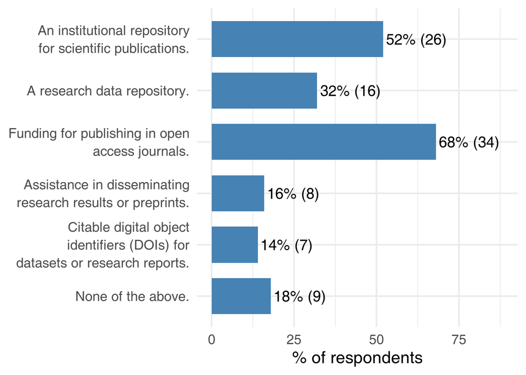

## [S3] Are you familiar with any repositories, sites, or tools suitable for experimental philosophy, such as the following?

| Option | n | % |
| --- | --- | --- |
| Preprint publication platforms. | 39 | 78.00 |
| None of the above. | 10 | 20.00 |
| Online databases of replication studies. | 8 | 16.00 |
| Online databases of null results. | 7 | 14.00 |
| Journals that publish null results. | 7 | 14.00 |
| Data journals. | 1 | 2.00 |

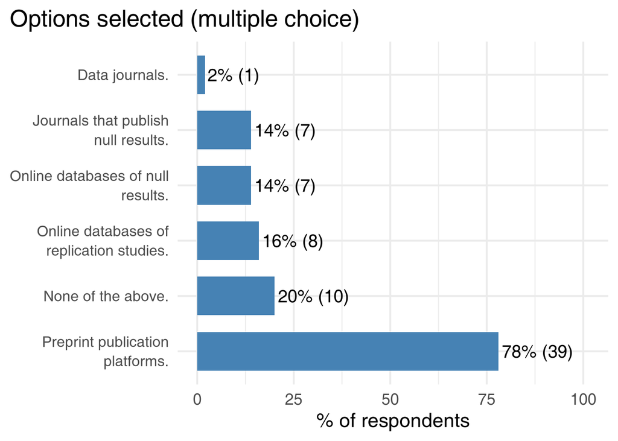

| Question | response |
| --- | --- |
| Preprint publication platforms. | PsyArxiv, ResearchGate, PhilPapers, etc. |
| Journals that publish null results. | Analysis, Cognition, Journal of Intelligence, Philosophical Studies, Review of Philosophy and Psychology, |
| Preprint publication platforms. | PsyArxiv |
| Journals that publish null results. | Many journals that publish experimental philosophy are open to null results |
| Preprint publication platforms. | PsyArxiv |
| Preprint publication platforms. | OSF |
| Data journals. | nature springer's data journal? |
| Preprint publication platforms. | psyarxiv |
| Preprint publication platforms. | arxiv, philpapers, osf |
| Journals that publish null results. | Phil Psychology, Episteme, Mind&Language (no x-phi anymore, unfortunately) |
| Preprint publication platforms. | PhilPapers, OSF |
| Journals that publish null results. | Philosophical Psychology? (I think most journals would consider.) |
| Preprint publication platforms. | arxive, osf |
| Online databases of replication studies. | https://forrt-replications.shinyapps.io/fred_explorer/ |
| Preprint publication platforms. | https://osf.io/preprints |
| Online databases of null results. | osf.io |
| Online databases of replication studies. | osf.io |
| Preprint publication platforms. | osf.io, philpapers.org, psyarxiv.com |
| Preprint publication platforms. | arxiv |
| Preprint publication platforms. | arXive, PsyArXiv, PhilSci-Archive, SSRN |
| Preprint publication platforms. | Phisci-archive |
| Online databases of null results. | Osf |
| Online databases of replication studies. | Osf |
| Preprint publication platforms. | PhilPapers |
| Preprint publication platforms. | OSF, philpaper |
| Preprint publication platforms. | psyarxiv |
| Online databases of null results. | OSF |
| Online databases of replication studies. | OSF |
| Preprint publication platforms. | PhilPapers |
| Preprint publication platforms. | philarchive, arxiv |
| Online databases of null results. | OSF, PsychFileDrawer |
| Online databases of replication studies. | OSF, PsychFileDrawer |
| Preprint publication platforms. | OSF preprints, PhilArchive, PhilSciArchive, PsyArXiv, arXiv |
| Online databases of null results. | OSF |
| Online databases of replication studies. | OSF |
| Preprint publication platforms. | research gate, academia |
| Preprint publication platforms. | PhilPapers |
| Preprint publication platforms. | PsyArxiv |
| Preprint publication platforms. | PhilPapers |
| Preprint publication platforms. | arxiv |
| Preprint publication platforms. | https://philsci-archive.pitt.edu, philpapers.org |
| Preprint publication platforms. | PhilPapers; PhilSciArchive; PsyArchiv |
| Preprint publication platforms. | arXiv, PhilArchive, PhilSci-Archive |
| Preprint publication platforms. | Ssrn |
| Preprint publication platforms. | Psyxarviv, philpapers |
| Preprint publication platforms. | e.g., PhilSci-Archive |
| Journals that publish null results. | e.g., Synthese, Philosophical Studies |
| Preprint publication platforms. | arxiv |
| Online databases of null results. | osf |
| Online databases of replication studies. | osf |
| Preprint publication platforms. | philpapers, philsci, osf |
| Preprint publication platforms. | Philpapers; Researchgate |
| Preprint publication platforms. | Psyarxiv, arXiv, philpapers |
| Preprint publication platforms. | OSF, PhilPapers, ArXiv |
| Preprint publication platforms. | SSRN, Arxiv, ResearchGate |
| Preprint publication platforms. | osf, psyarxiv, philpapers |
| Journals that publish null results. | https://www.jasnh.com/ |

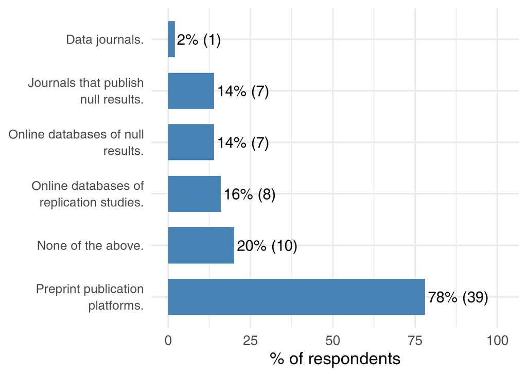

## [S4] Please indicate whether you are currently engaging in or planning to engage in the following activities:

[output not shown]

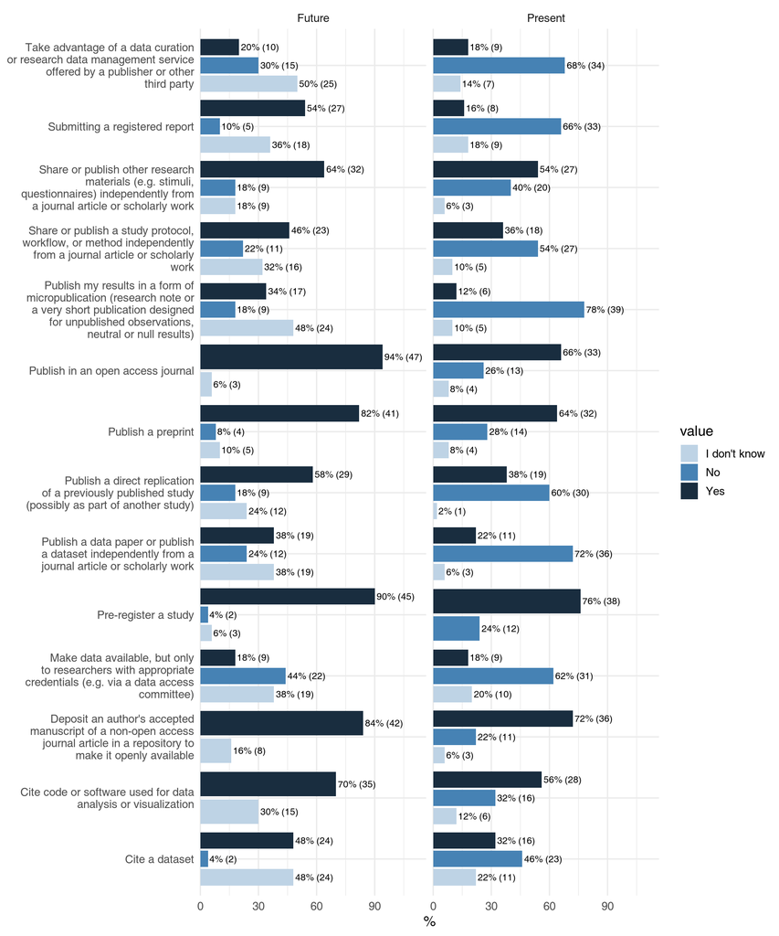

[output not shown]

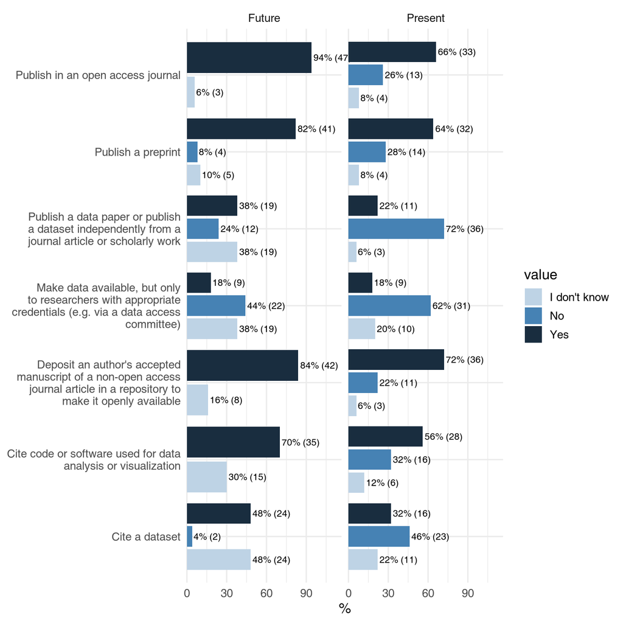

[output not shown]

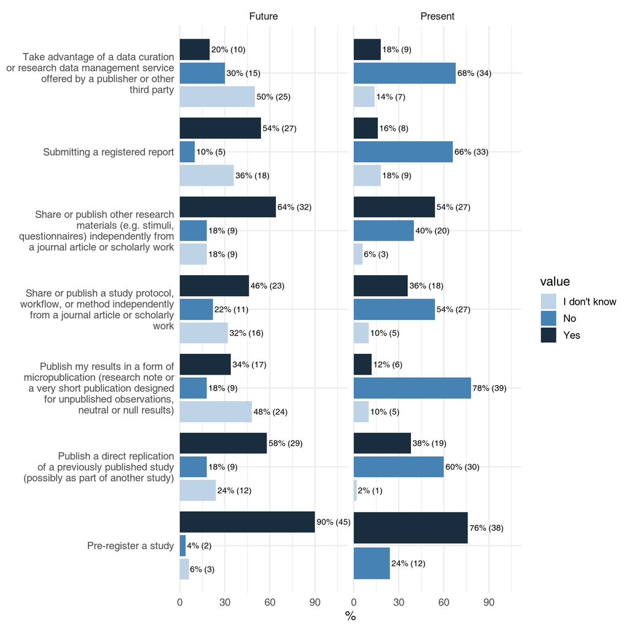

# [S5] Below is a list of potential reasons why researchers might not publish their data, code, or research reports. Please rate how much each reason applies to you or your research.

| Scale | n | M | SD | SE |
| --- | --- | --- | --- | --- |
| Extra effort that feels overwhelming amidst other responsibilities. | 50 | 3.36 | 1.47 | 0.21 |
| Lack of direct benefits, rewards, or incentives for the time and effort required to prepare data, code, or reports. | 50 | 2.74 | 1.41 | 0.20 |
| Pressure to publish in high-impact journals, leaving little time to ensure reproducibility or share materials. | 50 | 2.48 | 1.33 | 0.19 |
| Lack of training or skills (e.g., no expertise in formatting or preparing data/code/reports). | 50 | 2.34 | 1.29 | 0.18 |
| Desire to maintain a competitive advantage (e.g., worry that others might use the data to produce competing publications before the original authors can). | 50 | 2.10 | 1.20 | 0.17 |
| Journal policies that do not require sharing supplementary materials. | 50 | 2.00 | 1.21 | 0.17 |
| Fear of criticism or the possibility of exposing errors. | 50 | 1.96 | 1.12 | 0.16 |
| Technical challenges (e.g., issues with compatibility, version control, or documentation of code or data). | 50 | 1.94 | 1.04 | 0.15 |
| Restrictions imposed by funding agencies, commercial partners, or collaborative agreements. | 50 | 1.78 | 1.13 | 0.16 |
| Fear of misuse or misrepresentation of the data/code. | 50 | 1.70 | 1.13 | 0.16 |
| Concerns about intellectual property or ownership issues. | 50 | 1.60 | 1.01 | 0.14 |

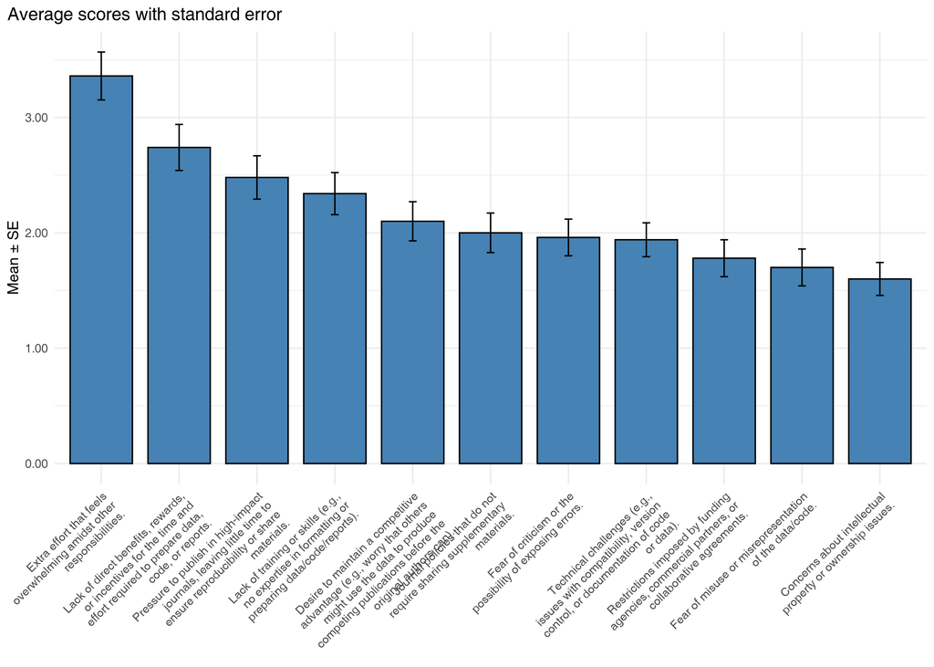

| Question | response |
| --- | --- |
| Other | Business, laziness, forgetfulness |
| Other | Laziness |
| Other | The experiment was ill-conceived and the results are irrelevant for the rationale of the research |
| Other | There are basically no institutional rewards for providing this stuff, and curating it over time is burdensome |
| Other | student research not of sufficient quality; or, for a another project, results and topic were complex and there was difficulty figuring out how to best move forward empirically and theoretically, give… |
| Other | I think I've published open data/stimuli/analysis code on OSF for all projects I was one of the lead authors |

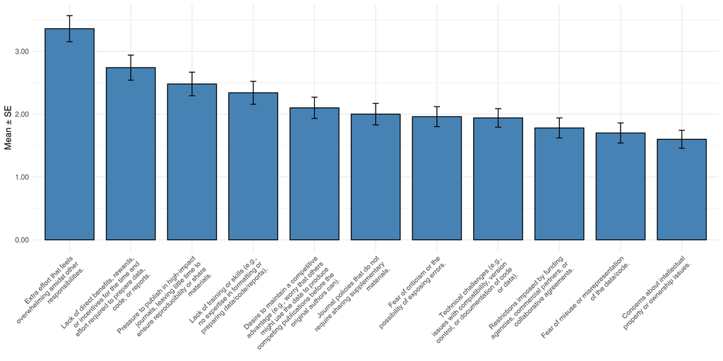

## [S6] Evaluate how the following incentives would motivate you to engage in open and transparent research practices, such as sharing data, code, or other research materials, publishing preprints, depositing manuscripts or datasets in open access repositories, citing data or software, pre-registering studies, and submitting registered reports.

| Scale | n | M | SD | SE |
| --- | --- | --- | --- | --- |
| Additional funding specifically designated to support these practices. | 50 | 3.96 | 1.24 | 0.18 |
| Standardized templates or guidelines for pre-registration, open reporting, dataset preparation, and other transparent research activities in experimental philosophy. | 50 | 3.66 | 1.22 | 0.17 |
| Including these practices in researcher evaluations or project assessments. | 50 | 3.46 | 1.40 | 0.20 |
| Availability of experimental philosophy-specific databases or repositories for data, materials, and code. | 50 | 3.38 | 1.47 | 0.21 |
| Assignment of a permanent DOI for datasets, pre-registrations, reports, preprints, or any additional materials. | 50 | 2.84 | 1.23 | 0.17 |

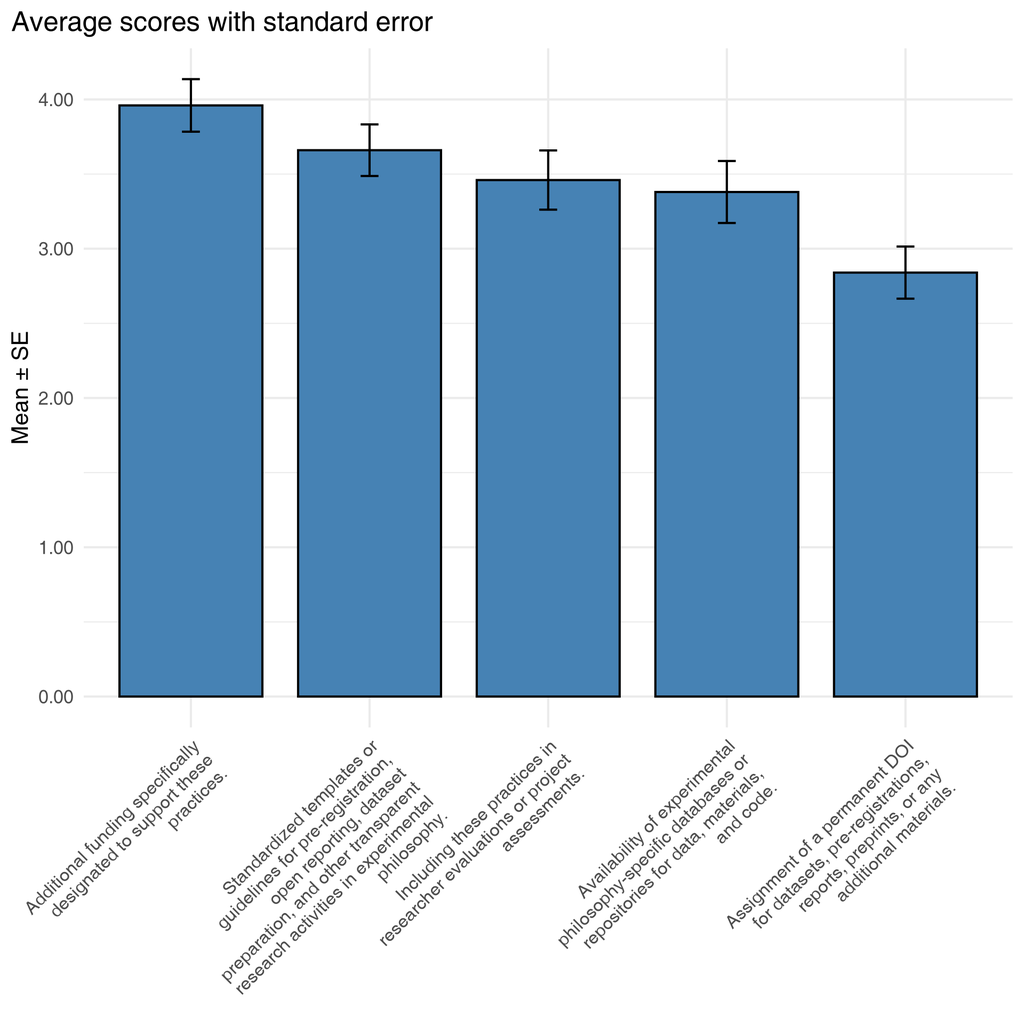

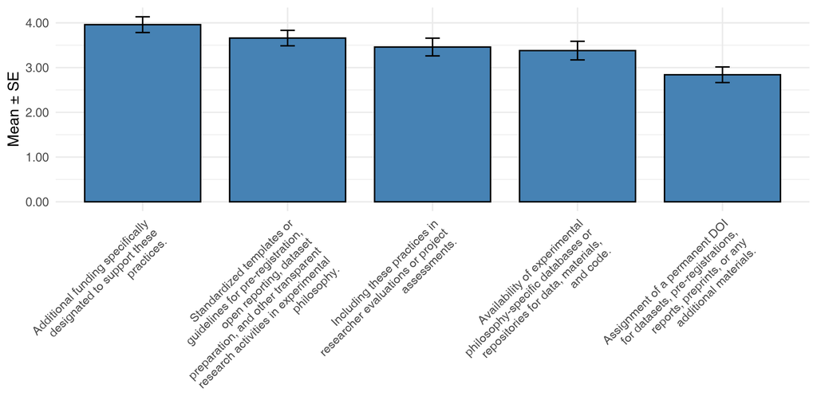

# Reports/micropublication

## [M1] Do you publish micropublications, eg., research notes or reports of unpublished studies, negative results, or failed replications?

| M1 | n | % |
| --- | --- | --- |
| Always | 0 | 0.00 |
| Often | 0 | 0.00 |
| Sometimes | 2 | 4.00 |
| Rarely | 7 | 14.00 |
| Never | 41 | 82.00 |

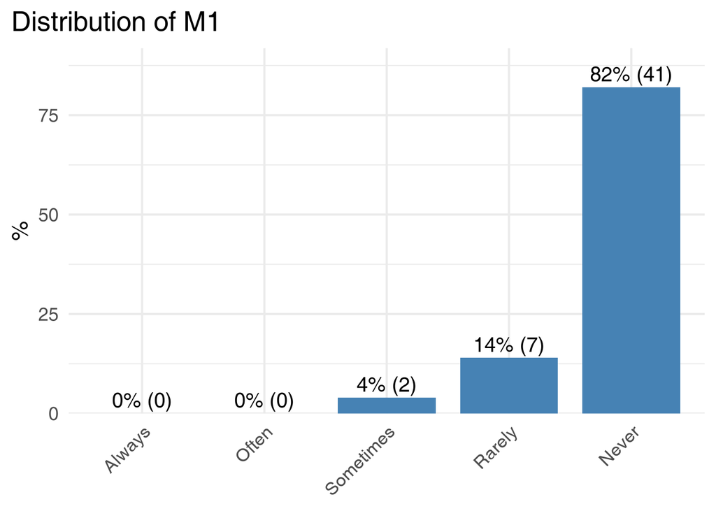

## [M2] Where do you publish micropublications?

| Option | n | % |
| --- | --- | --- |
| Personal website / blog | 5 | 10.00 |
| Open Science Framework (PsyArxiv) | 4 | 8.00 |
| Github | 4 | 8.00 |
| ResearchGate | 2 | 4.00 |

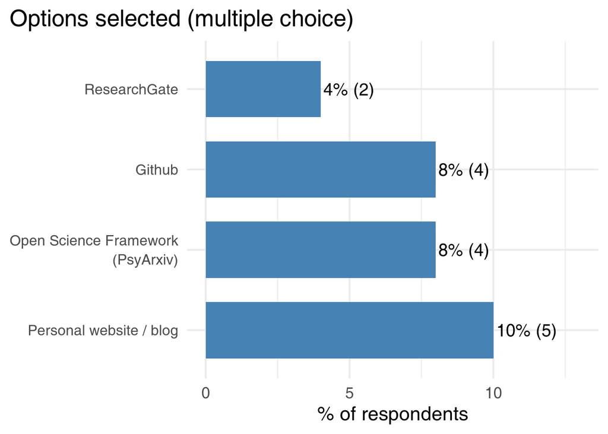

# Data sharing/publishing

## [H1] Have you ever archived, deposited, or published a dataset to make it available to others?

| Option | n | % |
| --- | --- | --- |
| Yes, I have shared my data using the Open Science Framework (OSF). | 41 | 82.00 |
| Yes, I have published my data as part of a journal article (e.g. sharing a full dataset as part of the supplementary materials). | 25 | 50.00 |
| No. | 7 | 14.00 |
| Yes, I have deposited my data in my institutional repository. | 5 | 10.00 |
| Yes, I have deposited my data into a general purpose repository besides the OSF (e.g figshare, Zenodo). | 4 | 8.00 |
| Yes, I have deposited my data in a government or funder sponsored repository (e.g. NIMH Data Archive). | 2 | 4.00 |
| Yes, I have deposited my data in a discipline-specific repository. | 0 | 0.00 |

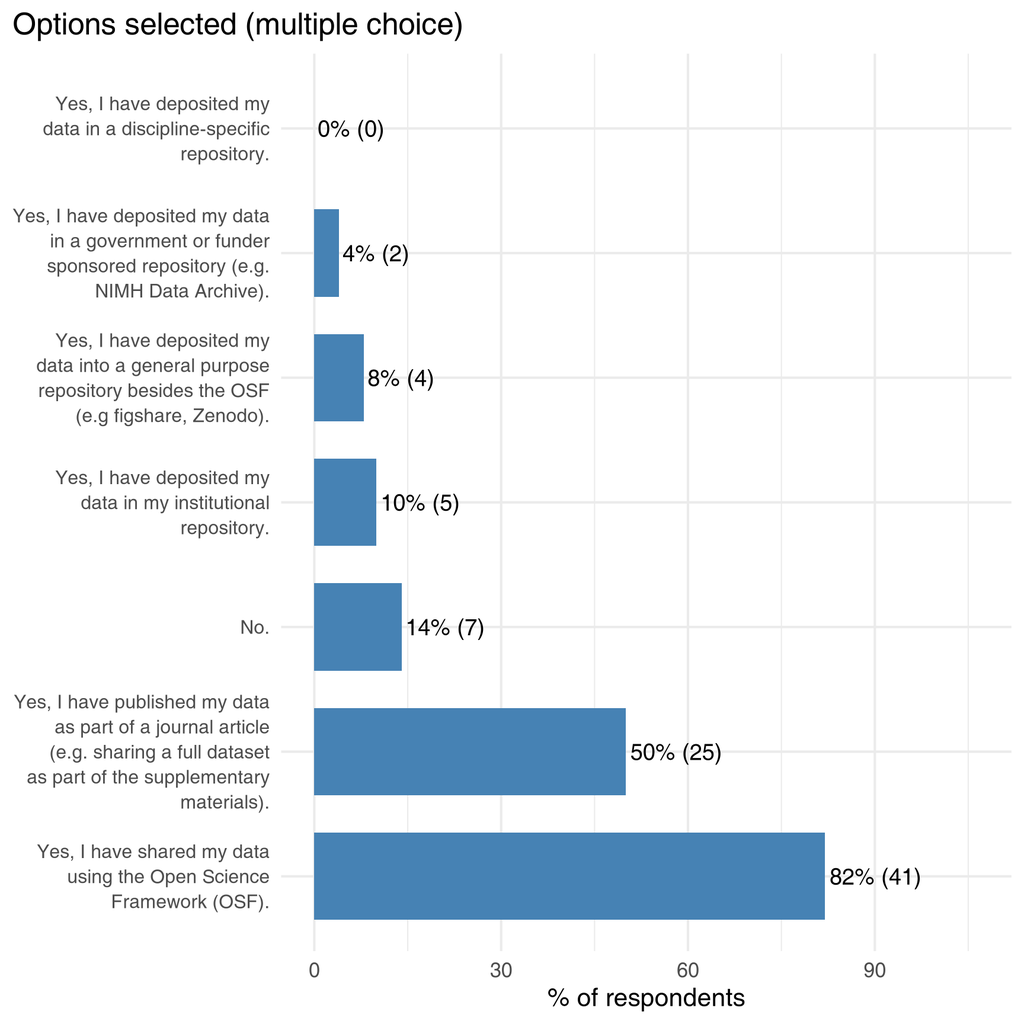

## [H2] What is your motivation for sharing your data (for example, by uploading some or all of it to a general or discipline-specific repository)?

| Option | n | % |
| --- | --- | --- |
| To allow other researchers to assess the validity of my conclusions. | 42 | 84.00 |
| To communicate my results and/or add to the scholarly literature. | 38 | 76.00 |
| To foster transparency and reproducibility. | 38 | 76.00 |
| To foster re-use (e.g. facilitate meta-analyses). | 35 | 70.00 |
| It is mandated by a funder, publisher, or my institution. | 11 | 22.00 |
| Professional incentives (e.g. authorship or citations). | 9 | 18.00 |
| To establish intellectual property or patent claims. | 2 | 4.00 |

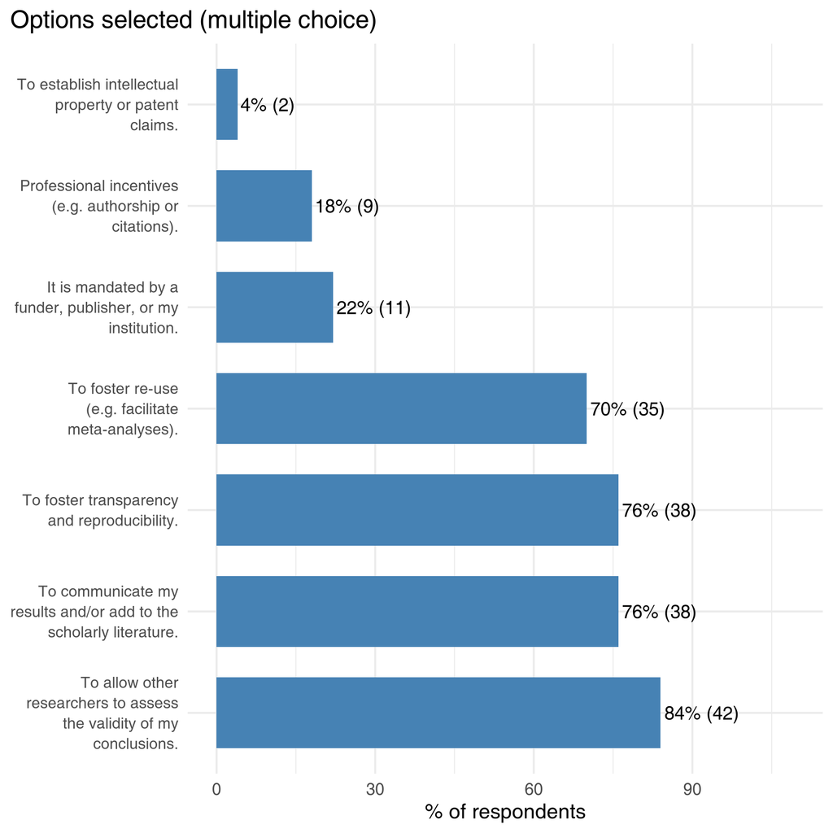

## [H4] Please indicate your level of need for training or education for each of the following data-sharing practices:

| Scale | n | M | SD | SE |
| --- | --- | --- | --- | --- |
| Best practices for preserving or archiving data over the long term. | 50 | 3.40 | 1.18 | 0.17 |
| Sharing data in a form that ensures it will be useful to others (e.g. in open file formats, with proper documentation, etc). | 50 | 3.16 | 1.48 | 0.21 |
| Understanding reuse rights related to data (e.g. copyright, licensing, citations). | 50 | 3.12 | 1.22 | 0.17 |
| Protecting participant confidentiality in shared data. | 50 | 2.70 | 1.33 | 0.19 |
| Use of different platforms, repositories, or tools for sharing data (e.g. Open Science Framework, figshare, institutional repository options). | 50 | 2.66 | 1.30 | 0.18 |

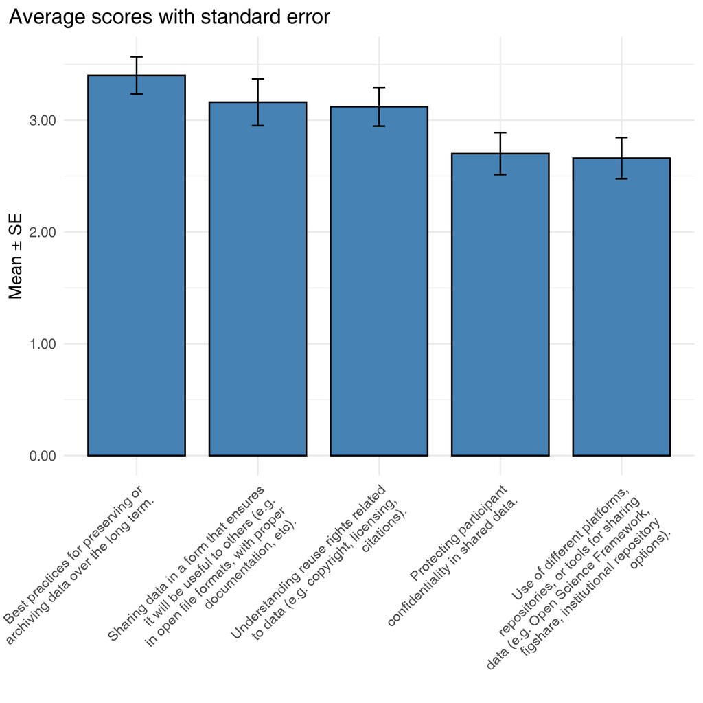

## [H3] How would you rate your willingness to change your data management practices during the data collection phase in response to new technologies, opportunities, or requirements?

| H3 | n | % |
| --- | --- | --- |
| 1 - Unwilling | 0 | 0.00 |
| 2 | 2 | 4.00 |
| 3 | 10 | 20.00 |
| 4 | 20 | 40.00 |
| 5 - Willing | 18 | 36.00 |

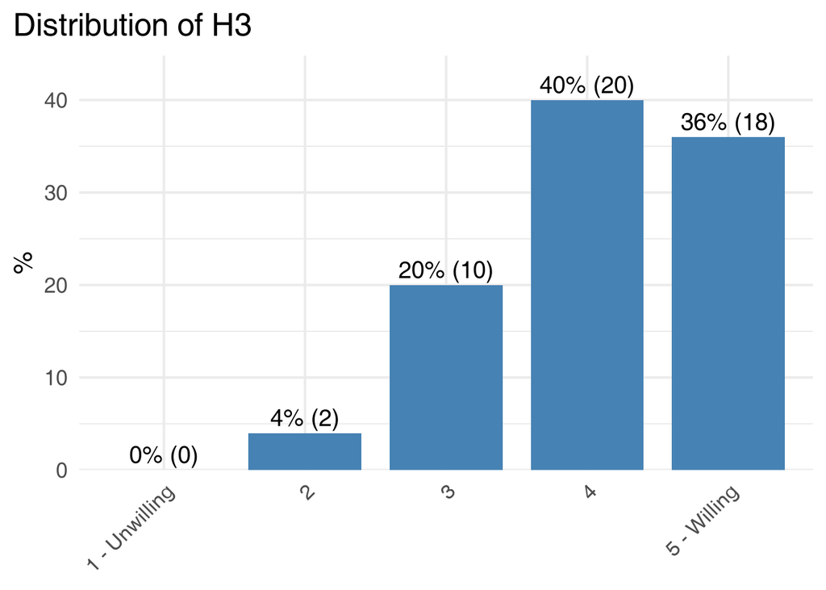

# Final Comments and Additional Information

| Question | response |
| --- | --- |
| Comments | The 47th President of the United States has appointed people who claim to be placing a higher priority on open science, especially for publicly funded science. The authenticity of the adminstration's … |
| Comments | So sorry, but I'm afraid I don't really remember the exact number of projects I've had over the past five years that didn't end up getting completed and published. So my answers to all of those questi… |
| Comments | This survey felt a bit long for me as a non-native English user. |
| Comments | As mentioned already, I mostly don't do experimental philosophy, except with some co-authors. |
| Comments | My practices have changed significantly as I've gained expertise. My early code will never see the light of data because it is horrendous. I could go through and clean it up for dissemination if the i… |
| Comments | As written in another write-in field: I've shared data/stimuli/analysis code for all of my papers. I do, however, have some file drawer problems of my own. Papers to which I collected a lot of data, b… |

# X-Phi vs The World

## Borghi & VanGulick 2020: `collect_change`,“Response to”“On a scale of 1-5, how would you rate your willingness to change your data management practices during the data collection phase of a project in response to new technologies, opportunities, or requirements?”“”

```
##
## -----------------------------------------------------------------------------------
##  Test statistic    df     P value   Alternative hypothesis   mean of x   mean of y
## ---------------- ------- --------- ------------------------ ----------- -----------
##     -0.1931       74.24   0.8474          two.sided            4.08        4.106
## -----------------------------------------------------------------------------------
##
## Table: Welch Two Sample t-test: `results$H3_numeric` and `borghi_vangulick2020$collect_change`
```

## Borghi & VanGulick 2020: `share_education`,

- `share_education_useful`,“Response to the question”“On a scale of 1 (No need) to 5 (High level of need), please indicate your level of need for training or education for each of the following - Sharing data in a form that ensures it will be useful to others”“.”

```
##
## --------------------------------------------------------------------------------
##  Test statistic   df   P value   Alternative hypothesis   mean of x   mean of y
## ---------------- ---- --------- ------------------------ ----------- -----------
##      0.5403       64   0.5908          two.sided            3.281       3.16
## --------------------------------------------------------------------------------
##
## Table: Welch Two Sample t-test: `borghi_vangulick2020$share_education_useful` and `results$`H4[SQ001]``
```

- `share_education_platforms`,“Response to the question”“On a scale of 1 (No need) to 5 (High level of need), please indicate your level of need for training or education for each of the following - Use of different platforms, repositories, or tools for sharing data”“.”

```
##
## ----------------------------------------------------------------------------
##  Test statistic    df       P value      Alternative hypothesis   mean of x
## ---------------- ------- -------------- ------------------------ -----------
##      2.743        70.96   0.007706 * *         two.sided            3.216
## ----------------------------------------------------------------------------
##
## Table: Welch Two Sample t-test: `borghi_vangulick2020$share_education_platforms` and `results$`H4[SQ002]`` (continued below)
##
##
## -----------
##  mean of y
## -----------
##    2.66
## -----------
```

- `share_education_confidentiality`,“Response to the question”“On a scale of 1 (No need) to 5 (High level of need), please indicate your level of need for training or education for each of the following - Protecting participant confidentiality in shared data”“.”

```
##
## -----------------------------------------------------------------------------------
##  Test statistic    df     P value   Alternative hypothesis   mean of x   mean of y
## ---------------- ------- --------- ------------------------ ----------- -----------
##      1.094        75.42   0.2772          two.sided            2.93         2.7
## -----------------------------------------------------------------------------------
##
## Table: Welch Two Sample t-test: `borghi_vangulick2020$share_education_confidentiality` and `results$`H4[SQ003]``
```

- `share_education_reuse`,“Response to the question”“On a scale of 1 (No need) to 5 (High level of need), please indicate your level of need for training or education for each of the following - Understanding reuse rights related to data”“.”

```
##
## -----------------------------------------------------------------------------------
##  Test statistic    df     P value   Alternative hypothesis   mean of x   mean of y
## ---------------- ------- --------- ------------------------ ----------- -----------
##      1.639        74.82   0.1054          two.sided            3.436       3.12
## -----------------------------------------------------------------------------------
##
## Table: Welch Two Sample t-test: `borghi_vangulick2020$share_education_reuse` and `results$`H4[SQ004]``
```

- `share_education_archiving`,“Response to the question”“On a scale of 1 (No need) to 5 (High level of need), please indicate your level of need for training or education for each of the following - Best practices for preserving or archiving data over the long term”“.”

```
##
## -----------------------------------------------------------------------------------
##  Test statistic    df     P value   Alternative hypothesis   mean of x   mean of y
## ---------------- ------- --------- ------------------------ ----------- -----------
##      1.484        74.51    0.142          two.sided            3.675        3.4
## -----------------------------------------------------------------------------------
##
## Table: Welch Two Sample t-test: `borghi_vangulick2020$share_education_archiving` and `results$`H4[SQ005]``
```

## Borghi & VanGulick 2020: `share_motivation`,

- `share_motivation`,“If the participant answered the question”“If applicable, what is your motivation for sharing your data (such as through uploading some or all of it to a general or discipline-specific repository)?”“. [1=Yes]”
- `share_motivation_results`,If the participant indicated that they are motivated to share data in order to communicate their results. [1=Yes]

```
##
## ----------------------------------------------------------------------------------
##  Test statistic   df       P value       Alternative hypothesis   prop 1   prop 2
## ---------------- ---- ----------------- ------------------------ -------- --------
##       14.3        1    0.0001562 * * *         two.sided          0.5639   0.8837
## ----------------------------------------------------------------------------------
##
## Table: 2-sample test for equality of proportions with continuity correction: `tab`
```

- `share_motivation_validity`,If the participant indicated that they are motivated to share data to allow other researchers to verify their claims. [1=Yes]

```
##
## ----------------------------------------------------------------------------------
##  Test statistic   df       P value       Alternative hypothesis   prop 1   prop 2
## ---------------- ---- ----------------- ------------------------ -------- --------
##      21.71        1    3.179e-06 * * *         two.sided          0.5947   0.9767
## ----------------------------------------------------------------------------------
##
## Table: 2-sample test for equality of proportions with continuity correction: `tab`
```

- `share_motivation_incentives`,If the participant indicated that they are motivated to share data by professional incentives. [1=Yes]

```
##
## --------------------------------------------------------------------------
##  Test statistic   df   P value   Alternative hypothesis   prop 1   prop 2
## ---------------- ---- --------- ------------------------ -------- --------
##     0.02577       1    0.8725          two.sided          0.185    0.2093
## --------------------------------------------------------------------------
##
## Table: 2-sample test for equality of proportions with continuity correction: `tab`
```

- `share_motivation_ip`,If the participant indicated that they are motivated to share data to establish IP claims. [1=Yes] share_motivation_mandate,“If the participant indicated that they are motivated to share data because it is mandated by a funder, publisher, or their institution. [1=Yes]”

```
##
## ----------------------------------------------------------------------------
##  Test statistic   df   P value   Alternative hypothesis   prop 1    prop 2
## ---------------- ---- --------- ------------------------ --------- ---------
##      0.7536       1    0.3853          two.sided          0.01322   0.04651
## ----------------------------------------------------------------------------
##
## Table: 2-sample test for equality of proportions with continuity correction: `tab`
```

- `share_motivation_mandate`,“If the participant indicated that they are motivated to share data because it is mandated by a funder, publisher, or their institution. [1=Yes]”

```
##
## --------------------------------------------------------------------------
##  Test statistic   df   P value   Alternative hypothesis   prop 1   prop 2
## ---------------- ---- --------- ------------------------ -------- --------
##     0.002224      1    0.9624          two.sided          0.2731   0.2558
## --------------------------------------------------------------------------
##
## Table: 2-sample test for equality of proportions with continuity correction: `tab`
```

- `share_motivation_transparency`,If the participant indicated that they are motivated to share data to foster transparency and reproducibility. [1=Yes]

```
##
## -------------------------------------------------------------------------------
##  Test statistic   df     P value      Alternative hypothesis   prop 1   prop 2
## ---------------- ---- -------------- ------------------------ -------- --------
##      6.702        1    0.009632 * *         two.sided          0.674    0.8837
## -------------------------------------------------------------------------------
##
## Table: 2-sample test for equality of proportions with continuity correction: `tab`
```

- `share_motivation_reuse`,If the participant indicated that they are motivated to share data to foster reuse. [1=Yes]

```
##
## -------------------------------------------------------------------------------
##  Test statistic   df     P value      Alternative hypothesis   prop 1   prop 2
## ---------------- ---- -------------- ------------------------ -------- --------
##      9.019        1    0.002672 * *         two.sided          0.5551   0.814
## -------------------------------------------------------------------------------
##
## Table: 2-sample test for equality of proportions with continuity correction: `tab`
```

## Borghi & VanGulick 2020: `share_archive`,

- `share_archive`,“If the participant answered the question”“Have you ever archived, deposited, or published a dataset in order to make it available to others?”“. [1=Yes]”
- `share_archive_article`,If the participant indicated that they have shared data as part of a journal article. [1=Yes]

```
##
## -------------------------------------------------------------------------------
##  Test statistic   df     P value      Alternative hypothesis   prop 1   prop 2
## ---------------- ---- -------------- ------------------------ -------- --------
##      8.616        1    0.003333 * *         two.sided          0.3319   0.5814
## -------------------------------------------------------------------------------
##
## Table: 2-sample test for equality of proportions with continuity correction: `tab`
```

- `share_archive_repo_government`,If the participant indicated that they have shared data through a government or funder sponsored repository. [1=Yes]

```
##
## ---------------------------------------------------------------------------
##  Test statistic   df   P value   Alternative hypothesis   prop 1   prop 2
## ---------------- ---- --------- ------------------------ -------- ---------
##     0.01657       1    0.8976          two.sided          0.0655   0.04651
## ---------------------------------------------------------------------------
##
## Table: 2-sample test for equality of proportions with continuity correction: `tab`
```

- `share_archive_OSF`,If the participant indicated that they have shared data through the OSF. [1=Yes]

```
##
## ---------------------------------------------------------------------------------
##  Test statistic   df      P value       Alternative hypothesis   prop 1   prop 2
## ---------------- ---- ---------------- ------------------------ -------- --------
##      35.47        1    2.59e-09 * * *         two.sided          0.4454   0.9535
## ---------------------------------------------------------------------------------
##
## Table: 2-sample test for equality of proportions with continuity correction: `tab`
```

- `share_archive_repo_other`If the participant indicated that they have shared data through a general purpose repository other than the OSF. [1=Yes]

```
##
## ---------------------------------------------------------------------------
##  Test statistic   df   P value   Alternative hypothesis   prop 1   prop 2
## ---------------- ---- --------- ------------------------ -------- ---------
##      0.1047       1    0.7462          two.sided          0.0655   0.09302
## ---------------------------------------------------------------------------
##
## Table: 2-sample test for equality of proportions with continuity correction: `tab`
```

- `share_archive_repo_disclipline`,If the participant indicated that they have shared data through a discipline specific repository. [1=Yes]
- `share_archive_repo_ir`,If the participant indicated that they have shared data through an institutional repository. [1=Yes]

```
##
## -----------------------------------------------------------------------------
##  Test statistic   df    P value    Alternative hypothesis   prop 1    prop 2
## ---------------- ---- ----------- ------------------------ --------- --------
##      4.438        1    0.03515 *         two.sided          0.03057   0.1163
## -----------------------------------------------------------------------------
##
## Table: 2-sample test for equality of proportions with continuity correction: `tab`
```

## Borghi & VanGulick 2020: `sc_activities`,

- `sc_activities_current_preprint`,“Response to”“Please indicate if you are currently doing any of the following activities as well as if you and if you plan do any in the future.”” for publishing preprints presently. ”
- `sc_activities_future_preprint`,“Response to”“Please indicate if you are currently doing any of the following activities as well as if you and if you plan do any in the future.”” for publishing preprints in the future.”

Comparison of Responses: Current and Future

| Timepoint | Response | B_and_VG_N | B_and_VG_Pct | Results_N | Results_Pct |
| --- | --- | --- | --- | --- | --- |
| Current | Yes | 96 | 44.2% | 32 | 64.0% |
| Current | No | 121 | 55.8% | 14 | 28.0% |
| Current | I don’t know | 0 | 0.0% | 4 | 8.0% |
| Future | Yes | 141 | 87.0% | 41 | 82.0% |
| Future | No | 21 | 13.0% | 4 | 8.0% |
| Future | I don’t know | 0 | 0.0% | 5 | 10.0% |

Chi-Squared Test Results

| Timepoint | Chi_Squared | df | p_value |
| --- | --- | --- | --- |
| Current | 26.86 | 2 | 1.468e-06 |
| Future | 17.11 | 2 | 0.0001925 |

- `sc_activities_current_oa_gold`,“Response to”“Please indicate if you are currently doing any of the following activities as well as if you and if you plan do any in the future.”” for publishing in an open access journal presently”
- `sc_activities_future_oa_gold`,“Response to”“Please indicate if you are currently doing any of the following activities as well as if you and if you plan do any in the future.”” for publishing in an open access journal in the future.”

Comparison of Responses: Current and Future

| Timepoint | Response | B_and_VG_N | B_and_VG_Pct | Results_N | Results_Pct |
| --- | --- | --- | --- | --- | --- |
| Current | Yes | 139 | 64.7% | 33 | 66.0% |
| Current | No | 76 | 35.3% | 13 | 26.0% |
| Current | I don’t know | 0 | 0.0% | 4 | 8.0% |
| Future | Yes | 186 | 96.4% | 47 | 94.0% |
| Future | No | 7 | 3.6% | 0 | 0.0% |
| Future | I don’t know | 0 | 0.0% | 3 | 6.0% |

Chi-Squared Test Results

| Timepoint | Chi_Squared | df | p_value |
| --- | --- | --- | --- |
| Current | 18.27 | 2 | 0.000108 |
| Future | 13.42 | 2 | 0.001221 |

- `sc_activities_current_oa_green`,“Response to”“Please indicate if you are currently doing any of the following activities as well as if you and if you plan do any in the future.”” for posting author manuscripts presently”
- `sc_activities_future_oa_green`,“Response to”“Please indicate if you are currently doing any of the following activities as well as if you and if you plan do any in the future.”” for posting author manuscripts in the future.”

Comparison of Responses: Current and Future

| Timepoint | Response | B_and_VG_N | B_and_VG_Pct | Results_N | Results_Pct |
| --- | --- | --- | --- | --- | --- |
| Current | Yes | 119 | 56.9% | 36 | 72.0% |
| Current | No | 90 | 43.1% | 11 | 22.0% |
| Current | I don’t know | 0 | 0.0% | 3 | 6.0% |
| Future | Yes | 147 | 86.5% | 42 | 84.0% |
| Future | No | 23 | 13.5% | 0 | 0.0% |
| Future | I don’t know | 0 | 0.0% | 8 | 16.0% |

Chi-Squared Test Results

| Timepoint | Chi_Squared | df | p_value |
| --- | --- | --- | --- |
| Current | 18.66 | 2 | 8.875e-05 |
| Future | 33.99 | 2 | 4.156e-08 |

- `sc_activities_current_cite_data`,“Response to”“Please indicate if you are currently doing any of the following activities as well as if you and if you plan do any in the future.”” for citing datasets presently. ”
- `sc_activities_future_cite_data`,“Response to”“Please indicate if you are currently doing any of the following activities as well as if you and if you plan do any in the future.”” for citing datasets in the future.”

Comparison of Responses: Current and Future

| Timepoint | Response | B_and_VG_N | B_and_VG_Pct | Results_N | Results_Pct |
| --- | --- | --- | --- | --- | --- |
| Current | Yes | 68 | 31.9% | 16 | 32.0% |
| Current | No | 145 | 68.1% | 23 | 46.0% |
| Current | I don’t know | 0 | 0.0% | 11 | 22.0% |
| Future | Yes | 113 | 89.0% | 24 | 48.0% |
| Future | No | 14 | 11.0% | 2 | 4.0% |
| Future | I don’t know | 0 | 0.0% | 24 | 48.0% |

Chi-Squared Test Results

| Timepoint | Chi_Squared | df | p_value |
| --- | --- | --- | --- |
| Current | 49.95 | 2 | 1.424e-11 |
| Future | 70.7 | 2 | 4.442e-16 |

- `sc_activities_current_cite_code`,“Response to”“Please indicate if you are currently doing any of the following activities as well as if you and if you plan do any in the future.”” for citing code presently. ”
- `sc_activities_future_cite_code`,“Response to”“Please indicate if you are currently doing any of the following activities as well as if you and if you plan do any in the future.”” for citing code in the future.”

Comparison of Responses: Current and Future

| Timepoint | Response | B_and_VG_N | B_and_VG_Pct | Results_N | Results_Pct |
| --- | --- | --- | --- | --- | --- |
| Current | Yes | 138 | 63.6% | 28 | 56.0% |
| Current | No | 79 | 36.4% | 16 | 32.0% |
| Current | I don’t know | 0 | 0.0% | 6 | 12.0% |
| Future | Yes | 156 | 94.0% | 35 | 70.0% |
| Future | No | 10 | 6.0% | 0 | 0.0% |
| Future | I don’t know | 0 | 0.0% | 15 | 30.0% |

Chi-Squared Test Results

| Timepoint | Chi_Squared | df | p_value |
| --- | --- | --- | --- |
| Current | 26.64 | 2 | 1.642e-06 |
| Future | 55.31 | 2 | 9.763e-13 |

- `sc_activities_current_data_paper`,“Response to”“Please indicate if you are currently doing any of the following activities as well as if you and if you plan do any in the future.”” for publishing datasets presently. ”
- `sc_activities_future_data_paper`,“Response to”“Please indicate if you are currently doing any of the following activities as well as if you and if you plan do any in the future.”” for publishing datasets in the future.”

Comparison of Responses: Current and Future

| Timepoint | Response | B_and_VG_N | B_and_VG_Pct | Results_N | Results_Pct |
| --- | --- | --- | --- | --- | --- |
| Current | Yes | 23 | 10.7% | 11 | 22.0% |
| Current | No | 192 | 89.3% | 36 | 72.0% |
| Current | I don’t know | 0 | 0.0% | 3 | 6.0% |
| Future | Yes | 59 | 48.8% | 19 | 38.0% |
| Future | No | 62 | 51.2% | 12 | 24.0% |
| Future | I don’t know | 0 | 0.0% | 19 | 38.0% |

Chi-Squared Test Results

| Timepoint | Chi_Squared | df | p_value |
| --- | --- | --- | --- |
| Current | 18.35 | 2 | 0.0001036 |
| Future | 52.94 | 2 | 3.186e-12 |

- `sc_activities_current_data_mediated`,“Response to”“Please indicate if you are currently doing any of the following activities as well as if you and if you plan do any in the future.”” for making data available to researchers with appropriate expertise presently. ”
- `sc_activities_future_data_mediated`,“Response to”“Please indicate if you are currently doing any of the following activities as well as if you and if you plan do any in the future.”” for making data available to researchers with appropriate expertise in the future.”
- `sc_activities_current_share_materials`,“Response to”“Please indicate if you are currently doing any of the following activities as well as if you and if you plan do any in the future.”” for sharing non-data research materials presently.”
- `sc_activities_future_share_materials`,“Response to”“Please indicate if you are currently doing any of the following activities as well as if you and if you plan do any in the future.”” for sharing non-data research materials in the future.”

Comparison of Responses: Current and Future

| Timepoint | Response | B_and_VG_N | B_and_VG_Pct | Results_N | Results_Pct |
| --- | --- | --- | --- | --- | --- |
| Current | Yes | 97 | 45.8% | 27 | 54.0% |
| Current | No | 115 | 54.2% | 20 | 40.0% |
| Current | I don’t know | 0 | 0.0% | 3 | 6.0% |
| Future | Yes | 134 | 83.8% | 32 | 64.0% |
| Future | No | 26 | 16.2% | 9 | 18.0% |
| Future | I don’t know | 0 | 0.0% | 9 | 18.0% |

Chi-Squared Test Results

| Timepoint | Chi_Squared | df | p_value |
| --- | --- | --- | --- |
| Current | 14.89 | 2 | 0.000583 |
| Future | 30.75 | 2 | 2.103e-07 |

- `sc_activities_current_share_protocol`,“Response to”“Please indicate if you are currently doing any of the following activities as well as if you and if you plan do any in the future.”” for sharing study protocols presently. ”
- `sc_activities_future_share_protocol`,“Response to”“Please indicate if you are currently doing any of the following activities as well as if you and if you plan do any in the future.”” for sharing study protocols in the future.”

Comparison of Responses: Current and Future

| Timepoint | Response | B_and_VG_N | B_and_VG_Pct | Results_N | Results_Pct |
| --- | --- | --- | --- | --- | --- |
| Current | Yes | 65 | 29.7% | 18 | 36.0% |
| Current | No | 154 | 70.3% | 27 | 54.0% |
| Current | I don’t know | 0 | 0.0% | 5 | 10.0% |
| Future | Yes | 108 | 72.0% | 23 | 46.0% |
| Future | No | 42 | 28.0% | 11 | 22.0% |
| Future | I don’t know | 0 | 0.0% | 16 | 32.0% |

Chi-Squared Test Results

| Timepoint | Chi_Squared | df | p_value |
| --- | --- | --- | --- |
| Current | 24.04 | 2 | 6.028e-06 |
| Future | 52.38 | 2 | 4.226e-12 |

- `sc_activities_current_preregister`,“Response to”“Please indicate if you are currently doing any of the following activities as well as if you and if you plan do any in the future.”” for preregistering a study presently. ”
- `sc_activities_future_preregister`,“Response to”“Please indicate if you are currently doing any of the following activities as well as if you and if you plan do any in the future.”” for preregistering a study in the future.”

Comparison of Responses: Current and Future

| Timepoint | Response | B_and_VG_N | B_and_VG_Pct | Results_N | Results_Pct |
| --- | --- | --- | --- | --- | --- |
| Current | Yes | 117 | 53.7% | 38 | 76.0% |
| Current | No | 101 | 46.3% | 12 | 24.0% |
| Current | I don’t know | 0 | 0.0% | 0 | 0.0% |
| Future | Yes | 165 | 92.7% | 45 | 90.0% |
| Future | No | 13 | 7.3% | 2 | 4.0% |
| Future | I don’t know | 0 | 0.0% | 3 | 6.0% |

Chi-Squared Test Results

| Timepoint | Chi_Squared | df | p_value |
| --- | --- | --- | --- |
| Current | 7.426 | 1 | 0.006429 |
| Future | 11.36 | 2 | 0.003416 |

- `sc_activities_current_register_report`,“Response to”“Please indicate if you are currently doing any of the following activities as well as if you and if you plan do any in the future.”” for publishing a registered report presently. ”
- `sc_activities_future_register_report`,“Response to”“Please indicate if you are currently doing any of the following activities as well as if you and if you plan do any in the future.”” for publishing a registered report in the future.”

Comparison of Responses: Current and Future

| Timepoint | Response | B_and_VG_N | B_and_VG_Pct | Results_N | Results_Pct |
| --- | --- | --- | --- | --- | --- |
| Current | Yes | 34 | 16.3% | 8 | 16.0% |
| Current | No | 174 | 83.7% | 33 | 66.0% |
| Current | I don’t know | 0 | 0.0% | 9 | 18.0% |
| Future | Yes | 123 | 85.4% | 27 | 54.0% |
| Future | No | 21 | 14.6% | 5 | 10.0% |
| Future | I don’t know | 0 | 0.0% | 18 | 36.0% |

Chi-Squared Test Results

| Timepoint | Chi_Squared | df | p_value |
| --- | --- | --- | --- |
| Current | 39.01 | 2 | 3.383e-09 |
| Future | 57.16 | 2 | 3.873e-13 |

- `sc_activities_current_curation`,“Response to”“Please indicate if you are currently doing any of the following activities as well as if you and if you plan do any in the future.”” for taking advantage of a data curation/RDM service presently. ”
- `sc_activities_future_curation`,“Response to”“Please indicate if you are currently doing any of the following activities as well as if you and if you plan do any in the future.”” for taking advantage of a data curation/RDM service in the future.”

Comparison of Responses: Current and Future

| Timepoint | Response | B_and_VG_N | B_and_VG_Pct | Results_N | Results_Pct |
| --- | --- | --- | --- | --- | --- |
| Current | Yes | 33 | 16.0% | 9 | 18.0% |
| Current | No | 173 | 84.0% | 34 | 68.0% |
| Current | I don’t know | 0 | 0.0% | 7 | 14.0% |
| Future | Yes | 66 | 63.5% | 10 | 20.0% |
| Future | No | 38 | 36.5% | 15 | 30.0% |
| Future | I don’t know | 0 | 0.0% | 25 | 50.0% |

Chi-Squared Test Results

| Timepoint | Chi_Squared | df | p_value |
| --- | --- | --- | --- |
| Current | 30.21 | 2 | 2.758e-07 |
| Future | 65.34 | 2 | 6.469e-15 |

- `sc_activities_current_replication`,“Response to”“Please indicate if you are currently doing any of the following activities as well as if you and if you plan do any in the future.”” for publishing a replication presently. ”
- `sc_activities_future_replication`,“Response to”“Please indicate if you are currently doing any of the following activities as well as if you and if you plan do any in the future.”” for publishing a replication in the future.”

Comparison of Responses: Current and Future

| Timepoint | Response | B_and_VG_N | B_and_VG_Pct | Results_N | Results_Pct |
| --- | --- | --- | --- | --- | --- |
| Current | Yes | 52 | 24.1% | 19 | 38.0% |
| Current | No | 164 | 75.9% | 30 | 60.0% |
| Current | I don’t know | 0 | 0.0% | 1 | 2.0% |
| Future | Yes | 100 | 78.1% | 29 | 58.0% |
| Future | No | 28 | 21.9% | 9 | 18.0% |
| Future | I don’t know | 0 | 0.0% | 12 | 24.0% |

Chi-Squared Test Results

| Timepoint | Chi_Squared | df | p_value |
| --- | --- | --- | --- |
| Current | 8.682 | 2 | 0.01302 |
| Future | 32.99 | 2 | 6.863e-08 |

## Larsson et al. 2023: QRPs,

| estimate | estimate1 | estimate2 | statistic | p.value | parameter | conf.low | conf.high | method | alternative | QRP |
| --- | --- | --- | --- | --- | --- | --- | --- | --- | --- | --- |
| -0.37 | 3.37 | 3.74 | -1.94 | 0.05 | 128.64 | -0.75 | 0.01 | Welch Two Sample t-test | two.sided | Selecting variables out of convenience and/or familiarity when more theoretically grounded variables are available |
| 0.07 | 4.16 | 4.09 | 0.35 | 0.73 | 161.49 | -0.32 | 0.46 | Welch Two Sample t-test | two.sided | Fishing for results by collecting information on unnecessary variables |
| -0.06 | 4.39 | 4.45 | -0.34 | 0.73 | 186.68 | -0.42 | 0.30 | Welch Two Sample t-test | two.sided | Not being transparent with regard to the reporting on what steps were taken for data cleaning (e.g., removing cases/items without a stated criterion or justification for doing so) |
| 0.06 | 4.80 | 4.74 | 0.34 | 0.74 | 231.58 | -0.27 | 0.38 | Welch Two Sample t-test | two.sided | Removing whole items/cases knowingly / purposefully to obtain favorable results |
| -0.05 | 4.16 | 4.21 | -0.26 | 0.79 | 167.47 | -0.42 | 0.32 | Welch Two Sample t-test | two.sided | Employing selective reporting of results/instruments |
| 0.06 | 4.41 | 4.35 | 0.30 | 0.76 | 176.17 | -0.32 | 0.44 | Welch Two Sample t-test | two.sided | Cherry-picking data to analyze |
| -1.05 | 2.42 | 3.47 | -5.49 | 0.00 | 132.39 | -1.43 | -0.67 | Welch Two Sample t-test | two.sided | Not attempting to publish results in a timely manner |